# CS544 Homework 5

### 1.b Draw 5000 samples of this data of size 10, show the histogram of the sample means.

Compute the mean of the sample means and the standard deviation of the sample means.

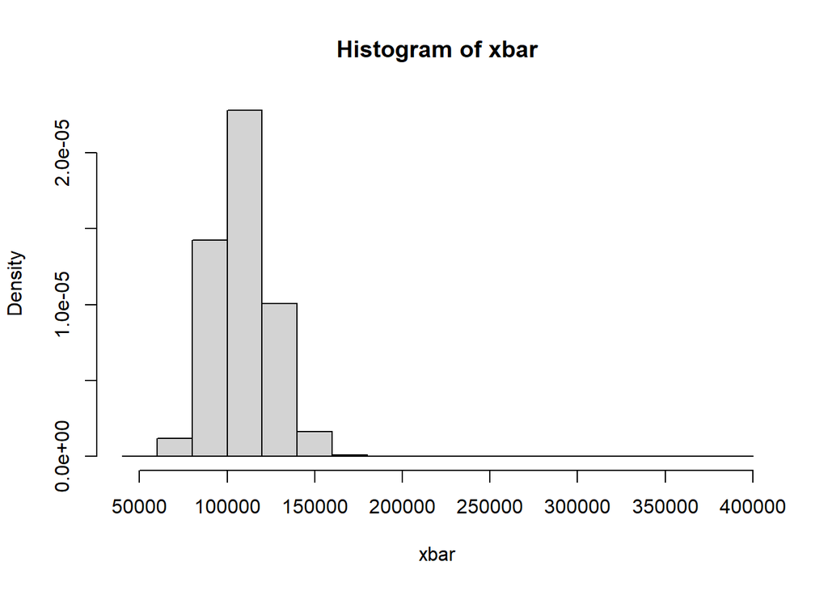

```r
samples <- 5000
sample.size <- 10

xbar <- numeric(samples)

for (i in 1: samples) {
    xbar[i] <- mean(sample(boston$Earnings, sample.size, replace = FALSE))
}

hist(xbar, prob = TRUE,
     breaks = s, xlim=c(40000,400000))
```

```r
# Computing the mean and standard deviation
mean10 <- dollar(mean(xbar))
sd10 <- dollar(sd(xbar))
```

### 1.c Draw 5000 samples of this data of size 40, show the histogram of the sample means.

Compute the mean of the sample means and the standard deviation of the sample means.

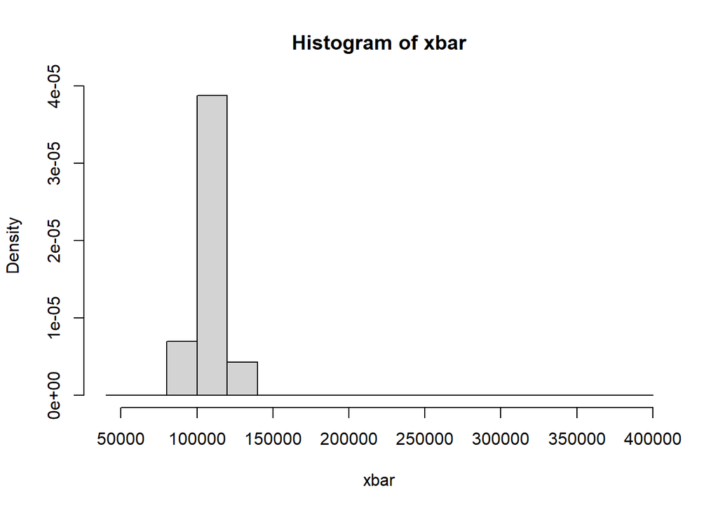

```r
samples <- 5000
sample.size <- 40

xbar <- numeric(samples)

for (i in 1: samples) {
    xbar[i] <- mean(sample(boston$Earnings, sample.size, replace = FALSE))
}
options(digits = 4)
hist(xbar, prob = TRUE,
     breaks = s, xlim=c(40000,400000))
```

```r
mean40 <- dollar(mean(xbar))
sd40 <- dollar(sd(xbar))
```

### 1.d Compare of means and standard deviations of the above three distributions.

```r
paste(" The mean and SD of the original dataset are ", mean0," and ", sd0)
```

```
## [1] " The mean and SD of the original dataset are  $108,681  and  $50,474.70"
```

```r
paste(" The mean and SD of the 10 sample sized dataset are ", mean10," and ",sd10)
```

```
## [1] " The mean and SD of the 10 sample sized dataset are  $108,626  and  $16,071.44"
```

```r
paste(" The mean and SD of the 40 sample sized  dataset are ", mean40," and ", sd40)
```

```
## [1] " The mean and SD of the 40 sample sized  dataset are  $108,695  and  $7,983.06"
```

```r
paste(" The mean became clear quickly with a small data set and the standard deviation changed quite a bit from the orgiinal.  To me this would point to outliers and could be investigated wtih a boxplot.")
```

```
## [1] " The mean became clear quickly with a small data set and the standard deviation changed quite a bit from the orgiinal.  To me this would point to outliers and could be investigated wtih a boxplot."
```

```r
#boxplot(boston$Earnings,horizontal = TRUE ))
```

## 2. Central Limit Theorem - Negative Binomial Distribution

```
Suppose the input data follows the negative binomial distribution with the parameters size = 3 and prob = .5
```

### 2.a Generate 5000 random values from this distribution. Show the barplot with the

proportions of the distinct values of this distribution.

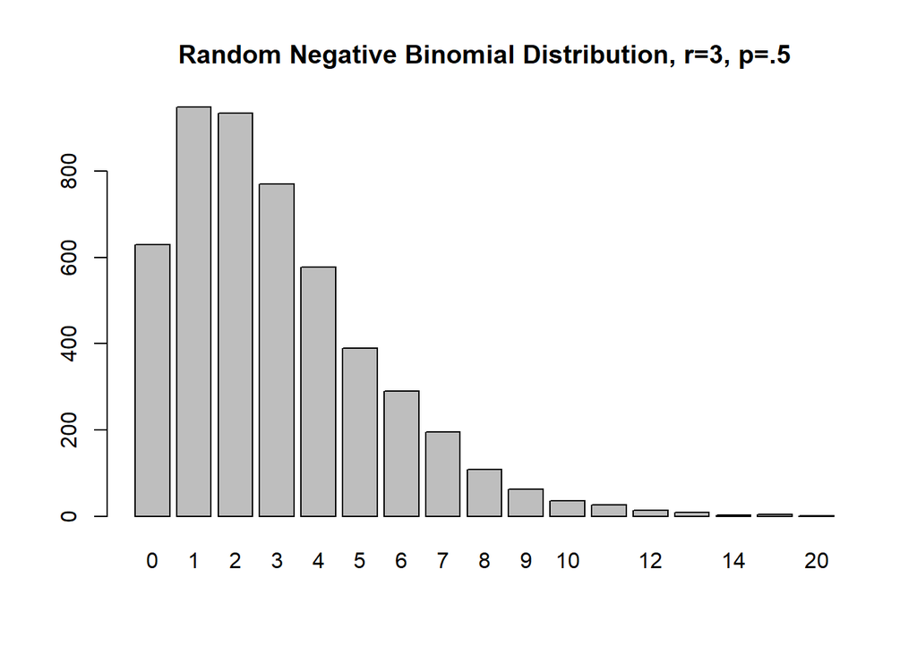

```r
# Probability
p <-  .5
# size
s <- 3

# Test plot
#x <- 0:30
#plot(dnbinom(x, size = s, prob = p))


x <- rnbinom(5000, size = s, prob = p)
barplot(table(x))
title("Random Negative Binomial Distribution, r=3, p=.5")
```

```r
mean(x)
```

```
## [1] 2.998
```

```r
sd(x)
```

```
## [1] 2.449
```

### 2.b With samples sizes of 10, 20, 30, and 40, draw 1000 samples from the data

generated in a). Use sample() function with replace as FALSE. Show the histograms of the densities of the sample means. Use a 2 x 2 layout.

```
## Sample Size =  10  Mean =  2.994  SD =  0.7881
```

```
## Sample Size =  20  Mean =  2.99  SD =  0.5403
```

```
## Sample Size =  30  Mean =  3  SD =  0.4351
```

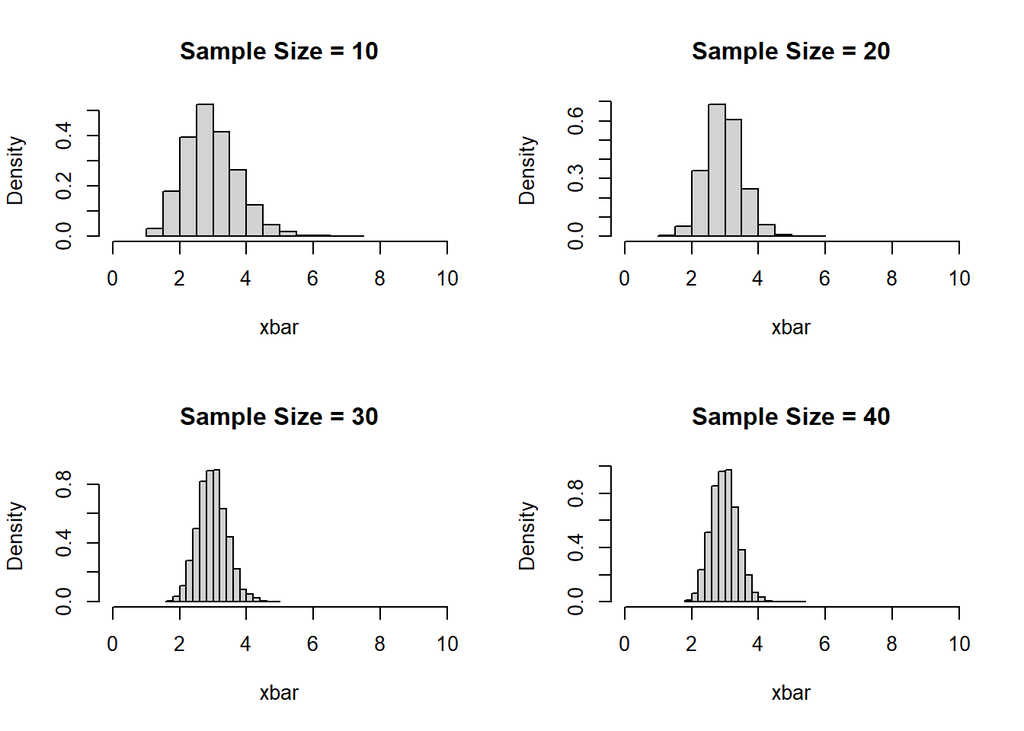

```
## Sample Size =  40  Mean =  2.995  SD =  0.3887
```

```r
par(mfrow = c(2,2))
p <-  .5
nbiSample <- 5000
# size
s <- 3
x <- rnbinom(nbiSample, size = s, prob = p)
xbar <-  numeric(nbiSample)

# x has been setup in previous code segment
for (size in c(10, 20, 30, 40)) {
    for (i in 1:nbiSample) {
      xbar[i] <- mean(sample(x, size, replace = FALSE))
    }

# Create a hist for each, arbitrarily kept the breaks at 15
   hist(xbar, prob = TRUE,
     breaks = 15, xlim=c(0,10),
     main = paste("Sample Size =", size))

   cat("Sample Size = ", size, " Mean = ", mean(xbar),
        " SD = ", sd(xbar), "\n")
}
```

```r
par(mfrow = c(1,1))

#10 / sqrt(c(10,20,30,40))
```

### 2.c Compare of means and standard deviations of the data from a) with the four

sequences generated in b).

```r
paste("With the four sample sizes changing, the mean was very accurate and the standard deviation was increasingly less as the sample size grew. Changing the nbiSample var from 5000 to 500 still resulted in values very close when the same sample size of 40 was used. ")
```

```
## [1] "With the four sample sizes changing, the mean was very accurate and the standard deviation was increasingly less as the sample size grew. Changing the nbiSample var from 5000 to 500 still resulted in values very close when the same sample size of 40 was used. "
```

## 3. Sampling

```
Create a subset of the dataset from #1 with only the top 5 departments based on the number of employees working in that department.
The top 5 should be computed using R code.  Use the %in% operator.
Sampling size: 50 for each
Random seed: Last 4 of your BU id : 5121
```

```r
# Trying the %>% operator
# Created a sorted var, send it to table for a count, sort it by decreasing values and get the names
sortedDept <- boston$Department  %>% table() %>% sort(decreasing = TRUE) %>% names()

# Get the top 5 names
top5DepartmentNames <- sortedDept[1:5]

# Get a subset of the top 5 departments in a dataframe using the %in% operator
topDepartments <- subset(boston,boston$Department %in% top5DepartmentNames)
```

### 3.a Show the sample drawn using simple random sampling without replacement.

Show the frequencies for the selected departments. Show the percentages of these with respect to sample size.

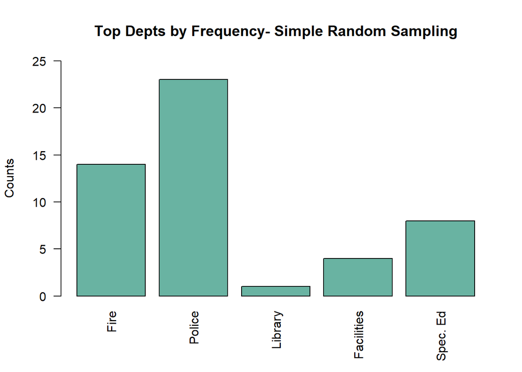

```r
# seed from BU id
set.seed(5121)
s <- srswor(50, nrow(topDepartments))

sample.2 <- topDepartments[s != 0, ]
#head(sample.2)

# Frequency table
t1 <- table(sample.2$Department)
#todo: Change naming convention on xaxis
barplot(t1, main =  "Top Depts by Frequency- Simple Random Sampling", ylab = "Counts",
          ylim=range(pretty(c(0, t1))),
        las = 2,
        names.arg=c("Fire","Police","Library","Facilities","Spec. Ed"),
        col="#69b3a2")
```

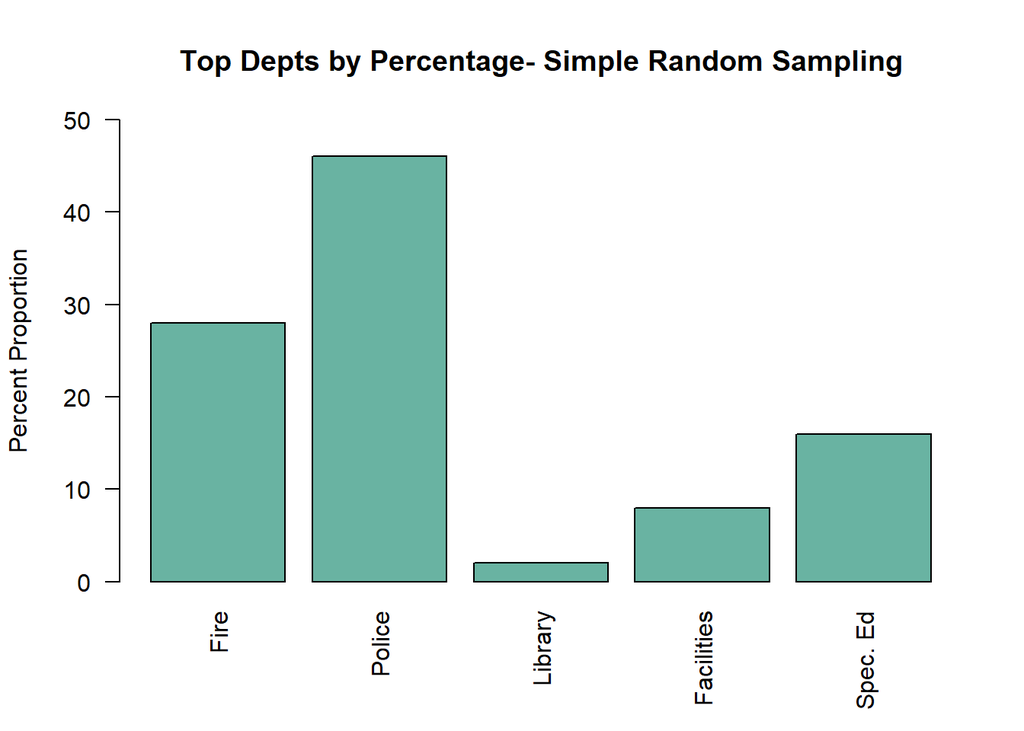

```r
# Proportion Table
t2<- prop.table(table(sample.2$Department)) * 100
#todo: Change naming convention on xaxis
# Renaming the prop table using the t var from above.
barplot(t2, main =  "Top Depts by Percentage- Simple Random Sampling", ylab = "Percent Proportion",
          ylim=range(pretty(c(0, t2))),
        las = 2,
        names.arg=c("Fire","Police","Library","Facilities","Spec. Ed"),
        col="#69b3a2")
```

### 3.b Show the sample drawn using systematic sampling.

Show the frequencies for the selected departments. Show the percentages of these with respect to sample size.

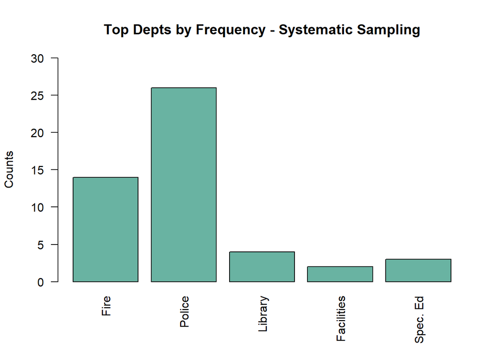

```r
set.seed(5121)
# sample size 50
N <- nrow(topDepartments)
n <- 50

k <- ceiling(N / n)
#k

r <- sample(k, 1)
#r

# select every kth item

s <- seq(r, by = k, length = n)

sample.3 <- topDepartments[s, ]
#head(sample.3)


# Cut and paste code from above.  dangerous..
# Frequency table
t3 <- table(sample.3$Department)
#todo: Change naming convention on xaxis
barplot(t3, main =  "Top Depts by Frequency - Systematic Sampling", ylab = "Counts",
          ylim=range(pretty(c(0, t3))),
        las = 2,
        names.arg=c("Fire","Police","Library","Facilities","Spec. Ed"),
        col="#69b3a2")
```

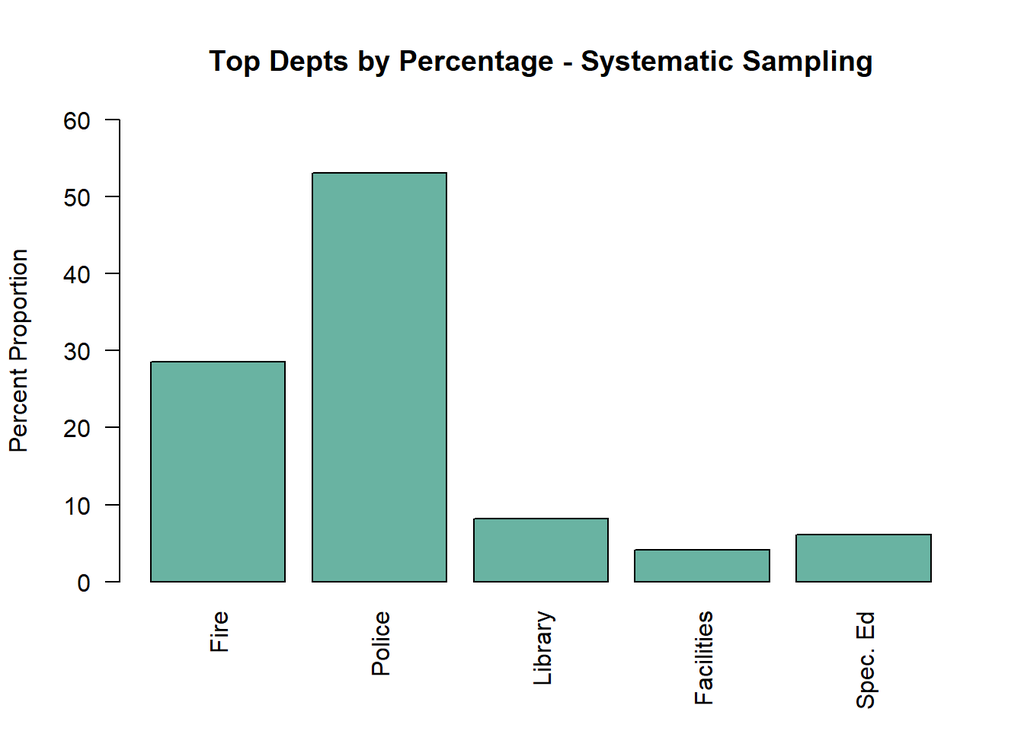

```r
# Proportion Table
t4<- prop.table(table(sample.3$Department)) * 100
#todo: Change naming convention on xaxis
# Renaming the prop table using the t var from above.
barplot(t4, main =  "Top Depts by Percentage - Systematic Sampling", ylab = "Percent Proportion",
          ylim=range(pretty(c(0, t4))),
        las = 2,
        names.arg=c("Fire","Police","Library","Facilities","Spec. Ed"),
        col="#69b3a2")
```

### 3.c Calculate the inclusion probabilities using the Earnings variable.

Using these values, show the sample drawn using systematic sampling with unequal probabilities. Show the frequencies for the selected departments. Show the percentages of these with respect to sample size.

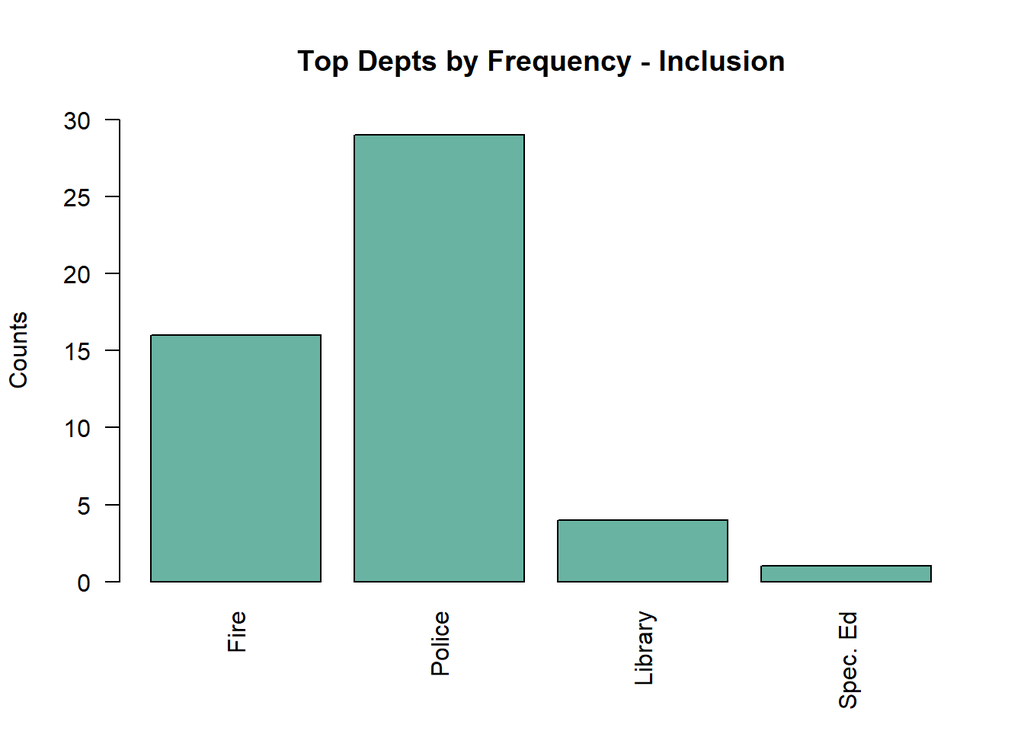

```r
# min i
#### 3.6. Unequal Probabilities
#inclusionprobabilities()

set.seed(5121)
# UPsystematic

pik <- inclusionprobabilities(
  topDepartments$Earnings, 50)
#length(pik)

#sum(pik)

s <- UPsystematic(pik)

sample.4 <- topDepartments[s != 0, ]
#head(sample.4)




# Cut and paste code from above.  dangerous..
# Frequency table
t5 <- table(sample.4$Department)
#todo: Change naming convention on xaxis
barplot(t5, main =  "Top Depts by Frequency - Inclusion", ylab = "Counts",
          ylim=range(pretty(c(0, t5))),
        las = 2,
        names.arg=c("Fire","Police","Library","Spec. Ed"),
        col="#69b3a2")
```

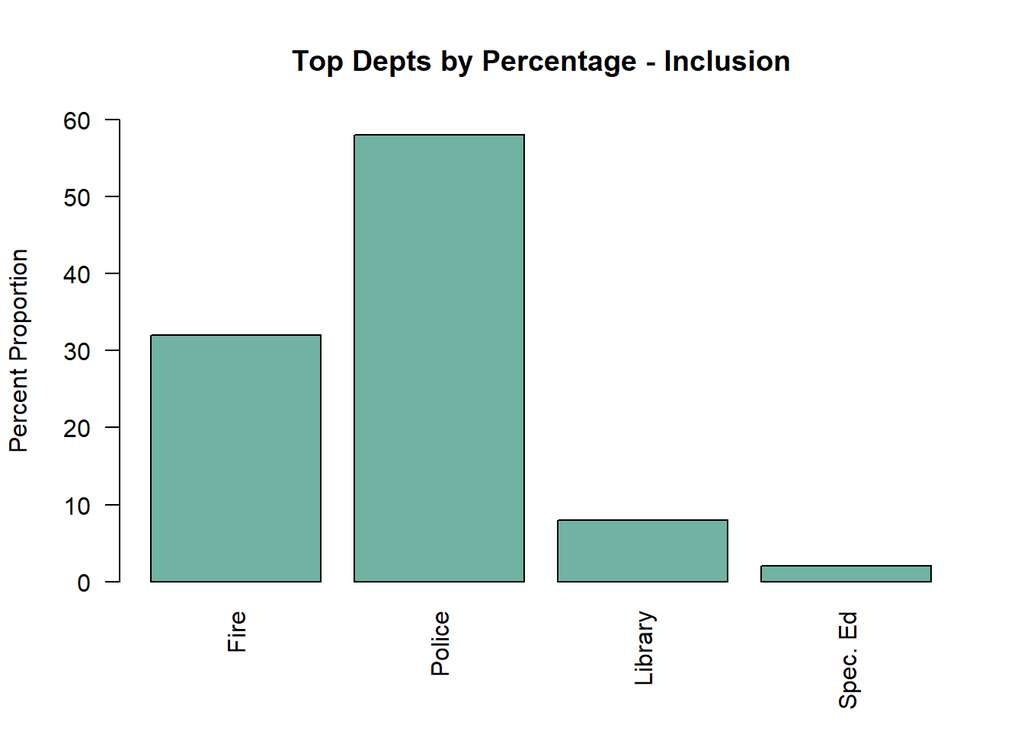

```r
# Proportion Table
t6<- prop.table(table(sample.4$Department)) * 100

#todo: Change naming convention on xaxis
# Renaming the prop table using the t var from above.
barplot(t6, main =  "Top Depts by Percentage - Inclusion", ylab = "Percent Proportion",
          ylim=range(pretty(c(0, t6))),
        las = 2,
        names.arg=c("Fire","Police","Library","Spec. Ed"),
        col="#70b3a2")
```